# Predicción del gasto corriente monetario de los hogares en México

## Predicción del gasto corriente monetario de los hogares en México mediante modelos de regresión

# 1. Introducción

El gasto de los hogares es un aspecto importante para comprender la situación económica de las familias y la manera en que distribuyen sus recursos. Factores como el nivel de ingreso, el número de integrantes del hogar, la cantidad de personas ocupadas y algunas características demográficas pueden estar relacionados con el nivel de gasto que realiza una familia.

En este proyecto se utilizarán datos reales de la Encuesta Nacional de Ingresos y Gastos de los Hogares 2024 (ENIGH), elaborada por el Instituto Nacional de Estadística y Geografía (INEGI), para analizar el gasto corriente monetario de los hogares en México.

El objetivo será identificar qué características económicas y demográficas están relacionadas con el gasto y evaluar qué tan bien puede estimarse mediante modelos de regresión. Para ello se comparará un modelo lineal con un modelo no lineal y posteriormente se realizará un análisis de inferencia estadística.

# 2. Planteamiento del problema

Los hogares mexicanos presentan diferencias importantes en sus niveles de ingreso, composición familiar y características socioeconómicas. Estas diferencias pueden influir en la cantidad de recursos que destinan al consumo y a la satisfacción de sus necesidades.

La pregunta principal que se busca responder en este análisis es:

¿Qué características económicas y demográficas de los hogares mexicanos están asociadas con su gasto corriente monetario y qué tan bien puede estimarse dicho gasto mediante modelos de regresión?

La variable de interés será el gasto corriente monetario del hogar, debido a que se trata de una variable cuantitativa continua. Por esta razón, el uso de modelos de regresión resulta adecuado para estudiar su relación con diferentes variables explicativas y generar estimaciones de su comportamiento.

El proyecto tendrá tanto un enfoque predictivo como inferencial. Por una parte, se comparará el desempeño de diferentes modelos para predecir el gasto; por otra, se analizará la asociación estadística entre las características seleccionadas y la variable de interés.

# 3. Objetivos

## Objetivo general

Analizar y estimar el gasto corriente monetario de los hogares en México mediante modelos de regresión utilizando información de la ENIGH 2024.

## Objetivos específicos

- Explorar la estructura y las características del conjunto de datos.
- Analizar la calidad de la información disponible.
- Identificar y tratar problemas presentes en los datos antes de construir los modelos.
- Seleccionar las variables más relevantes para explicar el gasto corriente monetario.
- Construir un modelo de regresión lineal.
- Construir un modelo de regresión no lineal.
- Evaluar y comparar el desempeño de ambos modelos mediante métricas adecuadas.
- Analizar la significancia estadística de las variables seleccionadas.
- Obtener intervalos de confianza para apoyar las inferencias realizadas.
- Identificar las principales limitaciones del análisis y plantear posibles mejoras.

# 4. Fuente y contexto de los datos

Los datos utilizados en este proyecto provienen de la Encuesta Nacional de Ingresos y Gastos de los Hogares 2024 (ENIGH), elaborada por el Instituto Nacional de Estadística y Geografía (INEGI).

La ENIGH recopila información sobre los ingresos, gastos y características socioeconómicas de los hogares mexicanos. Su diseño permite obtener información representativa a nivel nacional y por entidad federativa.

Para este análisis se utilizará la tabla CONCENTRADOHOGAR, que contiene información resumida a nivel hogar y concentra variables relacionadas con ingresos, gastos y distintas características de los hogares.

La variable que se utilizará como respuesta será el gasto corriente monetario, mientras que las variables explicativas se seleccionarán entre características económicas, demográficas y del hogar que no formen parte directamente del cálculo de dicho gasto.

# 5. Exploración y comprensión del conjunto de datos

Antes de construir los modelos de regresión es necesario conocer la estructura y el contenido de la base de datos. En esta sección se revisará el número de observaciones y variables, los nombres de las columnas, los tipos de datos y algunas observaciones iniciales.

También se evaluará posteriormente la calidad de la información para identificar posibles problemas que deban tratarse antes del modelado.

```python
import pandas as pd
import numpy as np
import matplotlib.pyplot as plt

# Cargar la base de datos de la ENIGH 2024
df = pd.read_csv(
    "concentradohogar.csv",
    dtype={
        "folioviv": str,
        "foliohog": str,
        "ubica_geo": str,
        "est_dis": str,
        "upm": str
    },
    low_memory=False
)

print("Base de datos cargada correctamente.")
print("Número de hogares:", df.shape[0])
print("Número de variables:", df.shape[1])
```

```
Base de datos cargada correctamente.
Número de hogares: 91414
Número de variables: 126
```

```python
df.head()
```

|  | folioviv | foliohog | ubica_geo | tam_loc | est_socio | est_dis | upm | factor | clase_hog | sexo_jefe | ... | mater_serv | material | servicio | deposito | prest_terc | pago_tarje | deudas | balance | otras_erog | smg |
| --- | --- | --- | --- | --- | --- | --- | --- | --- | --- | --- | --- | --- | --- | --- | --- | --- | --- | --- | --- | --- | --- |
| 0 | 0100001901 | 1 | 01001 | 1 | 3 | 001 | 0000001 | 207 | 2 | 1 | ... | 0.00 | 0.00 | 0.0 | 21365.21 | 0.00 | 0.00 | 8217.39 | 0.0 | 0.00 | 22403.7 |
| 1 | 0100001902 | 1 | 01001 | 1 | 3 | 001 | 0000001 | 207 | 2 | 1 | ... | 0.00 | 0.00 | 0.0 | 0.00 | 0.00 | 0.00 | 0.00 | 0.0 | 0.00 | 22403.7 |
| 2 | 0100001904 | 1 | 01001 | 1 | 3 | 001 | 0000001 | 207 | 2 | 2 | ... | 0.00 | 0.00 | 0.0 | 4695.65 | 0.00 | 0.00 | 0.00 | 0.0 | 0.00 | 22403.7 |
| 3 | 0100001905 | 1 | 01001 | 1 | 3 | 001 | 0000001 | 207 | 2 | 1 | ... | 366.84 | 366.84 | 0.0 | 5869.56 | 0.00 | 7336.95 | 2934.78 | 0.0 | 6260.86 | 22403.7 |
| 4 | 0100002501 | 1 | 01001 | 1 | 2 | 002 | 0000002 | 196 | 2 | 2 | ... | 0.00 | 0.00 | 0.0 | 0.00 | 2934.78 | 0.00 | 0.00 | 0.0 | 7113.91 | 22403.7 |

5 rows × 126 columns

```python
print("Variables disponibles en la base de datos:\n")

for i, columna in enumerate(df.columns, start=1):
    print(f"{i}. {columna}")
```

```
Variables disponibles en la base de datos:

1. folioviv
2. foliohog
3. ubica_geo
4. tam_loc
5. est_socio
6. est_dis
7. upm
8. factor
9. clase_hog
10. sexo_jefe
11. edad_jefe
12. educa_jefe
13. tot_integ
14. hombres
15. mujeres
16. mayores
17. menores
18. p12_64
19. p65mas
20. ocupados
21. percep_ing
22. perc_ocupa
23. ing_cor
24. ingtrab
25. trabajo
26. sueldos
27. horas_extr
28. comisiones
29. aguinaldo
30. indemtrab
31. otra_rem
32. remu_espec
33. negocio
34. noagrop
35. industria
36. comercio
37. servicios
38. agrope
```

[output cut: 73 more lines]

```
112. otras_perc
113. ero_nm_viv
114. ero_nm_hog
115. erogac_tot
116. cuota_viv
117. mater_serv
118. material
119. servicio
120. deposito
121. prest_terc
122. pago_tarje
123. deudas
124. balance
125. otras_erog
126. smg
```

## 5.1 Variables principales para el análisis

La base de datos contiene 126 variables. Sin embargo, no todas son adecuadas para utilizarse como variables explicativas del gasto corriente monetario. Algunas corresponden a identificadores, otras representan componentes directos del propio gasto y otras contienen información muy específica que no es necesaria para responder la pregunta de investigación.

Para facilitar la interpretación del análisis se consideran inicialmente las siguientes variables:

| Variable | Descripción |
| --- | --- |
| `gasto_mon` | Gasto corriente monetario trimestral del hogar |
| `ing_cor` | Ingreso corriente trimestral del hogar |
| `tot_integ` | Número total de integrantes del hogar |
| `ocupados` | Número de integrantes ocupados |
| `percep_ing` | Número de perceptores de ingreso |
| `edad_jefe` | Edad de la persona jefa del hogar |
| `educa_jefe` | Nivel educativo de la persona jefa del hogar |
| `sexo_jefe` | Sexo de la persona jefa del hogar |
| `tam_loc` | Tamaño de la localidad |
| `est_socio` | Estrato socioeconómico |
| `clase_hog` | Tipo o clase de hogar |

La selección definitiva de características se realizará posteriormente mediante el análisis de la información, evitando utilizar identificadores, variables redundantes o componentes directos del gasto que puedan generar fuga de información en el modelo.

```python
variables_iniciales = [
    "gasto_mon",
    "ing_cor",
    "tot_integ",
    "ocupados",
    "percep_ing",
    "edad_jefe",
    "educa_jefe",
    "sexo_jefe",
    "tam_loc",
    "est_socio",
    "clase_hog"
]

print("Tipos de datos de las variables iniciales:\n")
print(df[variables_iniciales].dtypes)
```

```
Tipos de datos de las variables iniciales:

gasto_mon     float64
ing_cor       float64
tot_integ       int64
ocupados        int64
percep_ing      int64
edad_jefe       int64
educa_jefe      int64
sexo_jefe       int64
tam_loc         int64
est_socio       int64
clase_hog       int64
dtype: object
```

```python
faltantes = df[variables_iniciales].isnull().sum()

print("Valores faltantes por variable:\n")
print(faltantes)

print("\nTotal de valores faltantes:", faltantes.sum())
```

```
Valores faltantes por variable:

gasto_mon     0
ing_cor       0
tot_integ     0
ocupados      0
percep_ing    0
edad_jefe     0
educa_jefe    0
sexo_jefe     0
tam_loc       0
est_socio     0
clase_hog     0
dtype: int64

Total de valores faltantes: 0
```

```python
duplicados = df.duplicated().sum()

print("Número de registros completamente duplicados:", duplicados)
```

```
Número de registros completamente duplicados: 0
```

```python
df[variables_iniciales].describe().T
```

|  | count | mean | std | min | 25% | 50% | 75% | max |
| --- | --- | --- | --- | --- | --- | --- | --- | --- |
| gasto_mon | 91414.0 | 43411.367667 | 38696.149251 | 0.0 | 21524.3275 | 34182.515 | 53047.1325 | 1635931.14 |
| ing_cor | 91414.0 | 72273.586289 | 93876.588278 | 0.0 | 34520.8725 | 55666.180 | 88840.7325 | 17431977.54 |
| tot_integ | 91414.0 | 3.374439 | 1.754476 | 1.0 | 2.0000 | 3.000 | 4.0000 | 20.00 |
| ocupados | 91414.0 | 1.632967 | 1.081635 | 0.0 | 1.0000 | 1.000 | 2.0000 | 13.00 |
| percep_ing | 91414.0 | 2.193034 | 1.148934 | 0.0 | 1.0000 | 2.000 | 3.0000 | 14.00 |
| edad_jefe | 91414.0 | 51.537281 | 15.994928 | 14.0 | 39.0000 | 51.000 | 63.0000 | 106.00 |
| educa_jefe | 91414.0 | 5.884132 | 2.575050 | 1.0 | 4.0000 | 6.000 | 8.0000 | 11.00 |
| sexo_jefe | 91414.0 | 1.323386 | 0.467771 | 1.0 | 1.0000 | 1.000 | 2.0000 | 2.00 |
| tam_loc | 91414.0 | 2.526965 | 1.335543 | 1.0 | 1.0000 | 3.000 | 4.0000 | 4.00 |
| est_socio | 91414.0 | 2.167830 | 0.856087 | 1.0 | 2.0000 | 2.000 | 3.0000 | 4.00 |
| clase_hog | 91414.0 | 2.121787 | 0.643906 | 1.0 | 2.0000 | 2.000 | 2.0000 | 5.00 |

## 5.2 Revisión inicial de la calidad de los datos

La revisión inicial mostró que las variables consideradas no presentan valores faltantes y que la base no contiene registros completamente duplicados. Por lo tanto, no será necesario realizar imputación de valores ni eliminar observaciones por duplicidad.

Sin embargo, la ausencia de datos faltantes o duplicados no significa que la información pueda utilizarse directamente en los modelos. Los resultados descriptivos muestran diferencias importantes entre los valores centrales y los valores máximos de algunas variables, principalmente en el ingreso y el gasto de los hogares.

Además, existen variables categóricas representadas mediante códigos numéricos, variables que contienen información redundante y otras que forman parte directamente del cálculo del gasto corriente monetario. Estos aspectos deberán revisarse y tratarse antes de construir los modelos de regresión.

```python
variables_numericas = [
    "gasto_mon",
    "ing_cor",
    "tot_integ",
    "ocupados",
    "percep_ing",
    "edad_jefe"
]

print("Revisión de posibles valores extremos mediante el método del IQR:\n")

for variable in variables_numericas:
    q1 = df[variable].quantile(0.25)
    q3 = df[variable].quantile(0.75)
    iqr = q3 - q1

    limite_inferior = q1 - 1.5 * iqr
    limite_superior = q3 + 1.5 * iqr

    cantidad = (
        (df[variable] < limite_inferior) |
        (df[variable] > limite_superior)
    ).sum()

    print(
        f"{variable}: {cantidad} observaciones fuera de los límites "
        f"({limite_inferior:.2f}, {limite_superior:.2f})"
    )
```

```
Revisión de posibles valores extremos mediante el método del IQR:

gasto_mon: 5193 observaciones fuera de los límites (-25759.88, 100331.34)
ing_cor: 4959 observaciones fuera de los límites (-46958.92, 170320.52)
tot_integ: 2040 observaciones fuera de los límites (-1.00, 7.00)
ocupados: 5149 observaciones fuera de los límites (-0.50, 3.50)
percep_ing: 357 observaciones fuera de los límites (-2.00, 6.00)
edad_jefe: 20 observaciones fuera de los límites (3.00, 99.00)
```

```python
print("Asimetría de las variables numéricas:\n")

for variable in variables_numericas:
    asimetria = df[variable].skew()
    print(f"{variable}: {asimetria:.3f}")
```

```
Asimetría de las variables numéricas:

gasto_mon: 5.493
ing_cor: 77.577
tot_integ: 0.955
ocupados: 0.905
percep_ing: 1.199
edad_jefe: 0.242
```

### Valores extremos y asimetría

El método del rango intercuartílico (IQR) identificó posibles valores extremos en varias de las variables numéricas. En particular, se encontraron 5,193 observaciones fuera de los límites calculados para `gasto_mon` y 4,959 para `ing_cor`.

Estos casos no se eliminarán automáticamente, ya que un ingreso o gasto elevado no necesariamente representa un error de captura. Al tratarse de información económica real, es posible que existan hogares con valores considerablemente mayores al resto.

El análisis de asimetría confirma que las distribuciones de ingreso y gasto presentan una cola derecha importante. `gasto_mon` obtuvo una asimetría de 5.493, mientras que `ing_cor` alcanzó 77.577.

Para reducir este problema sin eliminar observaciones válidas, se aplicará una transformación de raíz cúbica al gasto corriente monetario y una transformación logarítmica al ingreso corriente. Estas transformaciones reducen considerablemente la asimetría y permiten conservar todos los hogares de la muestra.

Las demás variables presentan niveles de asimetría considerablemente menores, por lo que no se aplicará una transformación automática sobre ellas.

```python
# Crear una copia para evitar advertencias de fragmentación
df = df.copy()

# Transformaciones para reducir la asimetría
df["gasto_transf"] = np.cbrt(df["gasto_mon"])
df["ingreso_log"] = np.log1p(df["ing_cor"])

print("Asimetría antes y después de la transformación:\n")

print(f"gasto_mon:    {df['gasto_mon'].skew():.3f}")
print(f"gasto_transf: {df['gasto_transf'].skew():.3f}")

print(f"\ning_cor:      {df['ing_cor'].skew():.3f}")
print(f"ingreso_log:  {df['ingreso_log'].skew():.3f}")
```

```
Asimetría antes y después de la transformación:

gasto_mon:    5.493
gasto_transf: 0.767

ing_cor:      77.577
ingreso_log:  -0.308
```

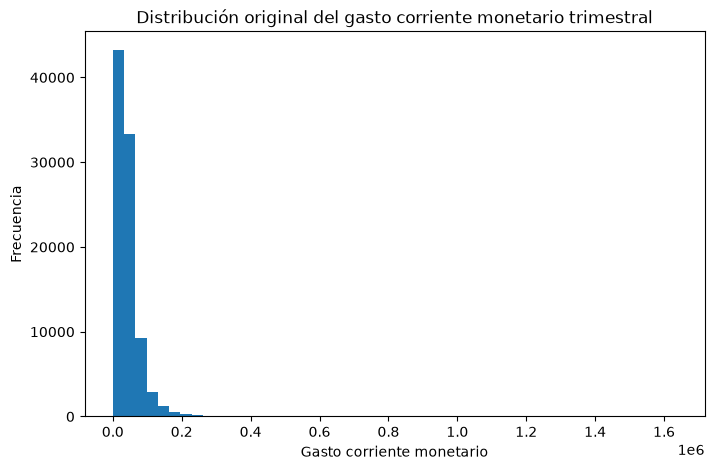

```python
plt.figure(figsize=(8, 5))

plt.hist(df["gasto_mon"], bins=50)

plt.title("Distribución original del gasto corriente monetario trimestral")
plt.xlabel("Gasto corriente monetario")
plt.ylabel("Frecuencia")

plt.show()
```

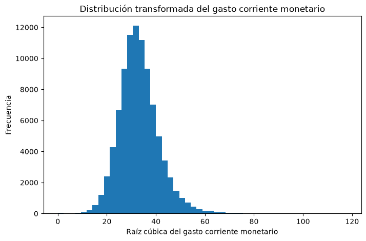

```python
plt.figure(figsize=(8, 5))

plt.hist(df["gasto_transf"], bins=50)

plt.title("Distribución transformada del gasto corriente monetario")
plt.xlabel("Raíz cúbica del gasto corriente monetario")
plt.ylabel("Frecuencia")

plt.show()
```

La distribución original del gasto corriente monetario presenta una concentración importante de observaciones en los valores bajos y medios, acompañada de una cola derecha extensa generada por hogares con gastos considerablemente mayores.

Después de aplicar la transformación de raíz cúbica, la distribución se vuelve más equilibrada y disminuye la influencia visual de los valores extremos. Esta transformación permite conservar todas las observaciones y trabajar con una variable de respuesta menos asimétrica.

Para la construcción de los modelos se utilizará la variable transformada. Al evaluar las predicciones finales, los resultados también se convertirán nuevamente a la escala monetaria original para facilitar su interpretación.

### Variables categóricas codificadas numéricamente

La exploración de los tipos de datos mostró que algunas variables aparecen almacenadas como números enteros, aunque en realidad representan categorías.

Esto ocurre con variables relacionadas con características del hogar y de la persona jefa, como el sexo, nivel educativo, tamaño de localidad, estrato socioeconómico y clase de hogar.

Estos códigos no deben interpretarse directamente como cantidades continuas. Por ejemplo, que una categoría tenga el código 2 en lugar de 1 no significa necesariamente que represente el doble de una característica. Por esta razón, antes del modelado será necesario dar un tratamiento adecuado a estas variables.

```python
variables_categoricas = [
    "educa_jefe",
    "sexo_jefe",
    "tam_loc",
    "est_socio",
    "clase_hog"
]

for variable in variables_categoricas:
    print(f"\nValores presentes en {variable}:")
    print(sorted(df[variable].unique()))
```

```
Valores presentes en educa_jefe:
[np.int64(1), np.int64(2), np.int64(3), np.int64(4), np.int64(5), np.int64(6), np.int64(7), np.int64(8), np.int64(9), np.int64(10), np.int64(11)]

Valores presentes en sexo_jefe:
[np.int64(1), np.int64(2)]

Valores presentes en tam_loc:
[np.int64(1), np.int64(2), np.int64(3), np.int64(4)]

Valores presentes en est_socio:
[np.int64(1), np.int64(2), np.int64(3), np.int64(4)]

Valores presentes en clase_hog:
[np.int64(1), np.int64(2), np.int64(3), np.int64(4), np.int64(5)]
```

### Variables redundantes

Otro aspecto importante antes del modelado es identificar variables que contienen información redundante.

En la base se dispone del número total de integrantes del hogar y también de variables que dividen a esos mismos integrantes por sexo y por grupos de edad. Incluir simultáneamente todas estas variables puede introducir información repetida y dificultar la interpretación de los coeficientes del modelo.

Por esta razón, se comprobará si el total de integrantes puede reconstruirse exactamente a partir de estas variables.

```python
coincidencia_sexo = (
    df["tot_integ"] == (df["hombres"] + df["mujeres"])
).mean() * 100

coincidencia_edad = (
    df["tot_integ"] == (df["mayores"] + df["menores"])
).mean() * 100

print(
    f"Coincidencia tot_integ = hombres + mujeres: "
    f"{coincidencia_sexo:.2f}%"
)

print(
    f"Coincidencia tot_integ = mayores + menores: "
    f"{coincidencia_edad:.2f}%"
)
```

```
Coincidencia tot_integ = hombres + mujeres: 100.00%
Coincidencia tot_integ = mayores + menores: 100.00%
```

Los resultados muestran una coincidencia del 100 % entre `tot_integ` y la suma de `hombres + mujeres`, así como entre `tot_integ` y la suma de `mayores + menores`.

Esto confirma que dichas variables contienen información redundante. Para evitar introducir relaciones determinísticas y multicolinealidad innecesaria en los modelos, se conservará `tot_integ` como medida general del tamaño del hogar y no se utilizarán simultáneamente sus componentes.

### Prevención de fuga de información

Además de la redundancia, es necesario evitar la fuga de información (*data leakage*). Este problema ocurre cuando se utilizan como predictores variables que contienen directa o indirectamente información de la variable que se desea estimar.

En este proyecto la variable objetivo original es `gasto_mon`. La base también contiene variables como alimentos, vivienda, transporte, salud, educación y otros rubros que forman parte del propio gasto corriente monetario.

Utilizar estos componentes para predecir el gasto total produciría un modelo artificialmente preciso, ya que se estaría utilizando parte de la respuesta para estimar la misma respuesta. Por esta razón, estos componentes del gasto fueron excluidos de las variables explicativas.

También se excluyeron identificadores y variables relacionadas únicamente con el diseño de la encuesta. El factor de expansión `factor` no se utilizó como predictor. El modelo de inferencia de este proyecto se enfocará en las asociaciones estadísticas observadas dentro de la muestra analizada y no pretende reproducir por completo el diseño muestral complejo utilizado por la ENIGH para generar estimaciones oficiales de población.

## 5.3 Preparación de las variables para el modelado

Después de revisar la calidad de los datos se definirá un conjunto inicial de características que puedan utilizarse para explicar el gasto sin introducir información redundante o fuga de información.

Se considerarán variables económicas, demográficas y relacionadas con la composición del hogar. El ingreso se utilizará en su versión logarítmica debido a la fuerte asimetría encontrada previamente.

Las variables categóricas serán transformadas mediante variables indicadoras (*dummy variables*). Para cada variable se eliminará una categoría de referencia, evitando introducir redundancia perfecta en los modelos.

La variable de respuesta utilizada durante el entrenamiento será `gasto_transf`, correspondiente a la raíz cúbica del gasto corriente monetario. Posteriormente, las predicciones serán convertidas nuevamente a la escala monetaria original para facilitar su interpretación.

```python
# Variables numéricas que se considerarán inicialmente
variables_numericas_modelo = [
    "ingreso_log",
    "tot_integ",
    "ocupados",
    "percep_ing",
    "edad_jefe"
]

# Variables que representan categorías
variables_categoricas_modelo = [
    "educa_jefe",
    "sexo_jefe",
    "tam_loc",
    "est_socio",
    "clase_hog"
]

# Crear conjunto inicial de predictores
X = df[
    variables_numericas_modelo +
    variables_categoricas_modelo
].copy()

# Convertir las variables categóricas en variables dummy
X = pd.get_dummies(
    X,
    columns=variables_categoricas_modelo,
    drop_first=True,
    dtype=int
)

# Variable respuesta transformada
y = df["gasto_transf"].copy()

print("Número de observaciones:", X.shape[0])
print("Número de características después de la codificación:", X.shape[1])
print("\nPrimeras características:")
print(X.columns.tolist())
```

```
Número de observaciones: 91414
Número de características después de la codificación: 26

Primeras características:
['ingreso_log', 'tot_integ', 'ocupados', 'percep_ing', 'edad_jefe', 'educa_jefe_2', 'educa_jefe_3', 'educa_jefe_4', 'educa_jefe_5', 'educa_jefe_6', 'educa_jefe_7', 'educa_jefe_8', 'educa_jefe_9', 'educa_jefe_10', 'educa_jefe_11', 'sexo_jefe_2', 'tam_loc_2', 'tam_loc_3', 'tam_loc_4', 'est_socio_2', '…
```

```python
print("Valores faltantes en X:", X.isnull().sum().sum())
print("Valores faltantes en y:", y.isnull().sum())

print("\nDimensiones de X:", X.shape)
print("Dimensiones de y:", y.shape)
```

```
Valores faltantes en X: 0
Valores faltantes en y: 0

Dimensiones de X: (91414, 26)
Dimensiones de y: (91414,)
```

# 6. Selección de características

Antes de construir los modelos se realizará un proceso de selección de características para identificar cuáles variables aportan mayor información para estimar el gasto.

La selección se realizará utilizando únicamente el conjunto de entrenamiento. De esta manera, el conjunto de prueba permanecerá completamente separado y podrá utilizarse posteriormente para evaluar el desempeño de los modelos con información que no participó en su construcción.

Esto también permite reducir variables poco informativas, facilitar la interpretación del modelo y disminuir la presencia de características innecesarias.

```python
from sklearn.model_selection import train_test_split

X_train, X_test, y_train, y_test = train_test_split(
    X,
    y,
    test_size=0.20,
    random_state=42
)

print("Conjunto de entrenamiento:")
print("X_train:", X_train.shape)
print("y_train:", y_train.shape)

print("\nConjunto de prueba:")
print("X_test:", X_test.shape)
print("y_test:", y_test.shape)
```

```
Conjunto de entrenamiento:
X_train: (73131, 26)
y_train: (73131,)

Conjunto de prueba:
X_test: (18283, 26)
y_test: (18283,)
```

## 6.1 Método de selección

Para seleccionar las características se utilizará el estadístico F de regresión mediante `SelectKBest`. Este método evalúa individualmente la relación entre cada característica y la variable de respuesta, asignando una puntuación mayor a aquellas variables que muestran una asociación más fuerte con el gasto transformado.

En lugar de elegir arbitrariamente un número fijo de variables, se evaluarán diferentes cantidades de características mediante validación cruzada de tres particiones utilizando únicamente el conjunto de entrenamiento.

Para cada cantidad de variables se ajustará un modelo de regresión lineal y se calculará el R² promedio obtenido durante la validación cruzada. Posteriormente se buscará un conjunto reducido de características cuyo desempeño sea cercano al mejor resultado observado.

Este procedimiento permite buscar un equilibrio entre capacidad predictiva y simplicidad del modelo, evitando conservar características que aporten muy poca mejora.

```python
from sklearn.feature_selection import SelectKBest, f_regression
from sklearn.linear_model import LinearRegression
from sklearn.pipeline import Pipeline
from sklearn.model_selection import KFold, cross_val_score

resultados_k = []

cv = KFold(
    n_splits=3,
    shuffle=True,
    random_state=42
)

for k in range(5, X_train.shape[1] + 1):

    pipeline = Pipeline([
        ("selector", SelectKBest(
            score_func=f_regression,
            k=k
        )),
        ("modelo", LinearRegression())
    ])

    scores = cross_val_score(
        pipeline,
        X_train,
        y_train,
        cv=cv,
        scoring="r2"
    )

    resultados_k.append({
        "k": k,
        "R2_promedio": scores.mean(),
        "desviacion": scores.std()
    })

resultados_k = pd.DataFrame(resultados_k)

resultados_k
```

|  | k | R2_promedio | desviacion |
| --- | --- | --- | --- |
| 0 | 5 | 0.527870 | 0.002661 |
| 1 | 6 | 0.529550 | 0.002584 |
| 2 | 7 | 0.537723 | 0.002075 |
| 3 | 8 | 0.541103 | 0.001258 |
| 4 | 9 | 0.547616 | 0.003571 |
| 5 | 10 | 0.553167 | 0.003476 |
| 6 | 11 | 0.554332 | 0.003567 |
| 7 | 12 | 0.554915 | 0.003561 |
| 8 | 13 | 0.555461 | 0.003411 |
| 9 | 14 | 0.556155 | 0.003517 |
| 10 | 15 | 0.556845 | 0.003572 |
| 11 | 16 | 0.558932 | 0.003637 |
| 12 | 17 | 0.560236 | 0.003283 |
| 13 | 18 | 0.561181 | 0.004062 |
| 14 | 19 | 0.561219 | 0.004031 |
| 15 | 20 | 0.561291 | 0.004074 |
| 16 | 21 | 0.561361 | 0.004149 |
| 17 | 22 | 0.561422 | 0.004194 |
| 18 | 23 | 0.561550 | 0.004280 |
| 19 | 24 | 0.561676 | 0.004187 |
| 20 | 25 | 0.562585 | 0.004018 |
| 21 | 26 | 0.562565 | 0.004026 |

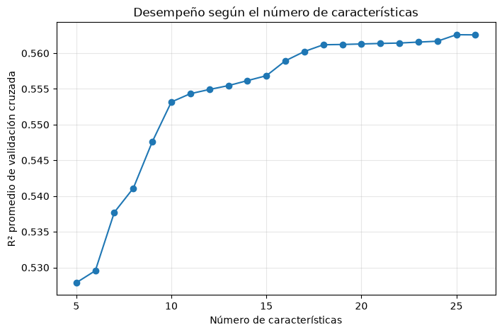

```python
plt.figure(figsize=(8, 5))

plt.plot(
    resultados_k["k"],
    resultados_k["R2_promedio"],
    marker="o"
)

plt.xlabel("Número de características")
plt.ylabel("R² promedio de validación cruzada")
plt.title("Desempeño según el número de características")

plt.grid(alpha=0.3)

plt.show()
```

```python
mejor_fila = resultados_k.loc[
    resultados_k["R2_promedio"].idxmax()
]

mejor_k = int(mejor_fila["k"])
mejor_r2 = mejor_fila["R2_promedio"]
mejor_desviacion = mejor_fila["desviacion"]

limite_desempeno = mejor_r2 - mejor_desviacion

k_elegido = int(
    resultados_k.loc[
        resultados_k["R2_promedio"] >= limite_desempeno,
        "k"
    ].min()
)

print(f"Mejor número de características: {mejor_k}")
print(f"Mejor R² promedio: {mejor_r2:.4f}")

print(
    f"\nNúmero de características elegido para un modelo más simple: "
    f"{k_elegido}"
)
```

```
Mejor número de características: 25
Mejor R² promedio: 0.5626

Número de características elegido para un modelo más simple: 16
```

```python
selector = SelectKBest(
    score_func=f_regression,
    k=k_elegido
)

selector.fit(X_train, y_train)

caracteristicas_seleccionadas = X_train.columns[
    selector.get_support()
].tolist()

print(
    f"Número de características seleccionadas: "
    f"{len(caracteristicas_seleccionadas)}"
)

print("\nCaracterísticas seleccionadas:")

for caracteristica in caracteristicas_seleccionadas:
    print("-", caracteristica)
```

```
Número de características seleccionadas: 16

Características seleccionadas:
- ingreso_log
- tot_integ
- ocupados
- percep_ing
- edad_jefe
- educa_jefe_3
- educa_jefe_4
- educa_jefe_8
- educa_jefe_9
- educa_jefe_10
- educa_jefe_11
- tam_loc_4
- est_socio_2
- est_socio_3
- est_socio_4
- clase_hog_3
```

```python
ranking_caracteristicas = pd.DataFrame({
    "Caracteristica": X_train.columns,
    "Puntuacion_F": selector.scores_,
    "p_value": selector.pvalues_,
    "Seleccionada": selector.get_support()
})

ranking_caracteristicas = ranking_caracteristicas.sort_values(
    by="Puntuacion_F",
    ascending=False
).reset_index(drop=True)

ranking_caracteristicas
```

|  | Caracteristica | Puntuacion_F | p_value | Seleccionada |
| --- | --- | --- | --- | --- |
| 0 | ingreso_log | 75237.377177 | 0.000000e+00 | True |
| 1 | est_socio_4 | 7220.263809 | 0.000000e+00 | True |
| 2 | educa_jefe_10 | 6932.948500 | 0.000000e+00 | True |
| 3 | ocupados | 6438.671745 | 0.000000e+00 | True |
| 4 | percep_ing | 6342.901103 | 0.000000e+00 | True |
| 5 | tam_loc_4 | 5998.032935 | 0.000000e+00 | True |
| 6 | tot_integ | 5591.220496 | 0.000000e+00 | True |
| 7 | educa_jefe_3 | 3337.825576 | 0.000000e+00 | True |
| 8 | educa_jefe_11 | 3268.197874 | 0.000000e+00 | True |
| 9 | edad_jefe | 1831.917781 | 0.000000e+00 | True |
| 10 | est_socio_3 | 1573.273202 | 0.000000e+00 | True |
| 11 | educa_jefe_4 | 1056.143831 | 4.947269e-230 | True |
| 12 | est_socio_2 | 737.391688 | 1.409345e-161 | True |
| 13 | clase_hog_3 | 668.821134 | 8.280573e-147 | True |
| 14 | educa_jefe_9 | 638.297638 | 3.143874e-140 | True |
| 15 | educa_jefe_8 | 623.975158 | 3.853103e-137 | True |
| 16 | clase_hog_2 | 544.655965 | 5.039793e-120 | False |
| 17 | sexo_jefe_2 | 520.646415 | 7.726856e-115 | False |
| 18 | clase_hog_5 | 122.546775 | 1.846097e-28 | False |
| 19 | tam_loc_3 | 107.297173 | 3.988381e-25 | False |
| 20 | tam_loc_2 | 103.917897 | 2.189536e-24 | False |
| 21 | clase_hog_4 | 62.849428 | 2.262566e-15 | False |
| 22 | educa_jefe_6 | 52.544270 | 4.247967e-13 | False |
| 23 | educa_jefe_5 | 44.955866 | 2.029840e-11 | False |
| 24 | educa_jefe_7 | 23.337104 | 1.362267e-06 | False |
| 25 | educa_jefe_2 | 7.758918 | 5.346171e-03 | False |

## 6.2 Resultados de la selección de características

La evaluación mediante validación cruzada mostró que el mayor R² promedio se obtuvo utilizando 25 características, con un valor aproximado de 0.5626. Sin embargo, el incremento en desempeño se vuelve pequeño conforme se agregan más variables.

Aplicando un criterio de simplificación, se eligió un conjunto de 16 características cuyo desempeño permanece cercano al mejor resultado obtenido. De esta manera se busca conservar una capacidad predictiva similar con un modelo más sencillo e interpretable.

La característica con mayor puntuación F fue `ingreso_log`, lo que indica una relación particularmente fuerte entre el ingreso corriente del hogar y el gasto transformado. También fueron seleccionadas características relacionadas con el estrato socioeconómico, el nivel educativo de la persona jefa del hogar, el número de ocupados, los perceptores de ingreso, el tamaño del hogar y el tamaño de la localidad.

La selección de características no implica que las variables descartadas no tengan ninguna relación con el gasto. Su exclusión responde a que, dentro del criterio utilizado, aportan una mejora limitada frente al conjunto reducido seleccionado.

A partir de este punto, los modelos predictivos utilizarán únicamente las 16 características seleccionadas.

# 7. Modelo 1: Regresión lineal múltiple

El primer modelo será una regresión lineal múltiple. Este modelo servirá como referencia para evaluar hasta qué punto una relación lineal entre las características seleccionadas permite estimar el gasto corriente monetario de los hogares.

La variable de respuesta utilizada para el entrenamiento será la raíz cúbica del gasto. Esta transformación fue seleccionada previamente para reducir la fuerte asimetría presente en la distribución original.

El modelo será entrenado únicamente con el conjunto de entrenamiento y su desempeño final será evaluado sobre el conjunto de prueba, que hasta este momento no ha participado en la selección de características ni en el ajuste del modelo.

```python
X_train_sel = X_train[caracteristicas_seleccionadas].copy()
X_test_sel = X_test[caracteristicas_seleccionadas].copy()

print("Dimensiones después de la selección:")
print("X_train_sel:", X_train_sel.shape)
print("X_test_sel:", X_test_sel.shape)
```

```
Dimensiones después de la selección:
X_train_sel: (73131, 16)
X_test_sel: (18283, 16)
```

```python
from sklearn.linear_model import LinearRegression

modelo_lineal = LinearRegression()

modelo_lineal.fit(X_train_sel, y_train)

pred_lineal_transf = modelo_lineal.predict(X_test_sel)

print("Modelo de regresión lineal entrenado correctamente.")
```

```
Modelo de regresión lineal entrenado correctamente.
```

```python
# Convertir valores reales y predicciones a la escala monetaria original
y_test_original = np.power(y_test.to_numpy(), 3)
pred_lineal_original = np.power(pred_lineal_transf, 3)

# Evitar predicciones monetarias negativas
pred_lineal_original = np.maximum(pred_lineal_original, 0)

print("Predicciones convertidas nuevamente a la escala monetaria original.")
```

```
Predicciones convertidas nuevamente a la escala monetaria original.
```

```python
from sklearn.metrics import mean_absolute_error, mean_squared_error, r2_score

mae_lineal = mean_absolute_error(
    y_test_original,
    pred_lineal_original
)

rmse_lineal = np.sqrt(
    mean_squared_error(
        y_test_original,
        pred_lineal_original
    )
)

r2_lineal_original = r2_score(
    y_test_original,
    pred_lineal_original
)

r2_lineal_transf = r2_score(
    y_test,
    pred_lineal_transf
)

print("Resultados del modelo de regresión lineal:\n")

print(f"MAE en escala monetaria:  ${mae_lineal:,.2f}")
print(f"RMSE en escala monetaria: ${rmse_lineal:,.2f}")
print(f"R² en escala monetaria:   {r2_lineal_original:.4f}")
print(f"R² en escala transformada: {r2_lineal_transf:.4f}")
```

```
Resultados del modelo de regresión lineal:

MAE en escala monetaria:  $15,006.06
RMSE en escala monetaria: $28,115.70
R² en escala monetaria:   0.4569
R² en escala transformada: 0.5695
```

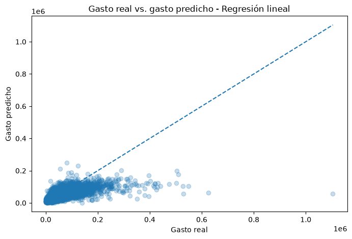

```python
plt.figure(figsize=(8, 5))

plt.scatter(
    y_test_original,
    pred_lineal_original,
    alpha=0.25
)

limite = max(
    y_test_original.max(),
    pred_lineal_original.max()
)

plt.plot(
    [0, limite],
    [0, limite],
    linestyle="--"
)

plt.xlabel("Gasto real")
plt.ylabel("Gasto predicho")
plt.title("Gasto real vs. gasto predicho - Regresión lineal")

plt.show()
```

## 7.1 Resultados e interpretación del modelo lineal

El modelo de regresión lineal obtuvo un MAE de aproximadamente **$15,006.06** en la escala monetaria original. Esto significa que, en promedio, las predicciones del gasto corriente monetario trimestral se alejan alrededor de 15 mil pesos del valor observado.

El RMSE fue de aproximadamente **$28,115.70**. Este valor es mayor que el MAE debido a que el RMSE penaliza con mayor intensidad los errores grandes, lo cual es consistente con la presencia de hogares con niveles de gasto considerablemente mayores al resto.

El R² calculado en la escala monetaria original fue de **0.4569**, lo que indica que el modelo explica aproximadamente el 45.69 % de la variabilidad observada en el gasto. En la escala transformada, utilizada durante el entrenamiento, el R² fue de **0.5695**.

La gráfica de valores reales contra valores predichos muestra que el modelo representa razonablemente el comportamiento de una parte importante de las observaciones, aunque presenta mayores dificultades en hogares con gastos muy elevados. En particular, algunos de estos valores extremos son subestimados por el modelo.

Estos resultados serán utilizados como punto de referencia para evaluar si un modelo no lineal puede representar mejor las relaciones presentes en los datos.

# 8. Modelo 2: Regresión polinomial

Como segundo modelo se utilizará una regresión polinomial de grado 2. Este modelo permite representar relaciones no lineales mediante términos cuadrados e interacciones entre las variables numéricas.

Se eligió un polinomio de segundo grado porque permite incorporar curvatura sin incrementar innecesariamente la complejidad del modelo. Las variables categóricas ya transformadas en variables indicadoras se conservarán de forma lineal, ya que aplicar potencias a estos códigos no aporta una interpretación útil.

El modelo utilizará el mismo conjunto de entrenamiento, conjunto de prueba y características seleccionadas que la regresión lineal, permitiendo realizar una comparación bajo las mismas condiciones.

```python
from sklearn.preprocessing import PolynomialFeatures

# Identificar las variables numéricas seleccionadas
variables_numericas_seleccionadas = [
    variable
    for variable in [
        "ingreso_log",
        "tot_integ",
        "ocupados",
        "percep_ing",
        "edad_jefe"
    ]
    if variable in caracteristicas_seleccionadas
]

# Las demás características seleccionadas corresponden a variables dummy
variables_dummy_seleccionadas = [
    variable
    for variable in caracteristicas_seleccionadas
    if variable not in variables_numericas_seleccionadas
]

# Crear términos polinomiales únicamente para las variables numéricas
poly = PolynomialFeatures(
    degree=2,
    include_bias=False
)

X_train_num_poly = poly.fit_transform(
    X_train_sel[variables_numericas_seleccionadas]
)

X_test_num_poly = poly.transform(
    X_test_sel[variables_numericas_seleccionadas]
)

nombres_poly = poly.get_feature_names_out(
    variables_numericas_seleccionadas
)

# Convertir a DataFrame
X_train_poly = pd.DataFrame(
    X_train_num_poly,
    columns=nombres_poly,
    index=X_train_sel.index
)

X_test_poly = pd.DataFrame(
    X_test_num_poly,
    columns=nombres_poly,
    index=X_test_sel.index
)

# Agregar las variables categóricas seleccionadas sin transformarlas
X_train_poly = pd.concat(
    [
        X_train_poly,
        X_train_sel[variables_dummy_seleccionadas]
    ],
    axis=1
)

X_test_poly = pd.concat(
    [
        X_test_poly,
        X_test_sel[variables_dummy_seleccionadas]
    ],
    axis=1
)

print("Variables numéricas utilizadas:")
print(variables_numericas_seleccionadas)

print("\nNúmero de características del modelo lineal:")
print(X_train_sel.shape[1])

print("\nNúmero de características del modelo polinomial:")
print(X_train_poly.shape[1])

print("\nDimensiones de entrenamiento:")
print(X_train_poly.shape)

print("\nDimensiones de prueba:")
print(X_test_poly.shape)
```

```
Variables numéricas utilizadas:
['ingreso_log', 'tot_integ', 'ocupados', 'percep_ing', 'edad_jefe']

Número de características del modelo lineal:
16

Número de características del modelo polinomial:
31

Dimensiones de entrenamiento:
(73131, 31)

Dimensiones de prueba:
(18283, 31)
```

```python
modelo_polinomial = LinearRegression()

modelo_polinomial.fit(
    X_train_poly,
    y_train
)

pred_polinomial_transf = modelo_polinomial.predict(
    X_test_poly
)

print("Modelo de regresión polinomial entrenado correctamente.")
```

```
Modelo de regresión polinomial entrenado correctamente.
```

```python
pred_polinomial_original = np.power(
    pred_polinomial_transf,
    3
)

# Evitar posibles predicciones monetarias negativas
pred_polinomial_original = np.maximum(
    pred_polinomial_original,
    0
)

print(
    "Predicciones del modelo polinomial convertidas "
    "a la escala monetaria original."
)
```

```
Predicciones del modelo polinomial convertidas a la escala monetaria original.
```

```python
mae_polinomial = mean_absolute_error(
    y_test_original,
    pred_polinomial_original
)

rmse_polinomial = np.sqrt(
    mean_squared_error(
        y_test_original,
        pred_polinomial_original
    )
)

r2_polinomial_original = r2_score(
    y_test_original,
    pred_polinomial_original
)

r2_polinomial_transf = r2_score(
    y_test,
    pred_polinomial_transf
)

print("Resultados del modelo de regresión polinomial:\n")

print(
    f"MAE en escala monetaria:  "
    f"${mae_polinomial:,.2f}"
)

print(
    f"RMSE en escala monetaria: "
    f"${rmse_polinomial:,.2f}"
)

print(
    f"R² en escala monetaria:   "
    f"{r2_polinomial_original:.4f}"
)

print(
    f"R² en escala transformada: "
    f"{r2_polinomial_transf:.4f}"
)
```

```
Resultados del modelo de regresión polinomial:

MAE en escala monetaria:  $14,833.79
RMSE en escala monetaria: $28,012.57
R² en escala monetaria:   0.4609
R² en escala transformada: 0.5870
```

```python
comparacion_modelos = pd.DataFrame({
    "Modelo": [
        "Regresión lineal",
        "Regresión polinomial"
    ],
    "MAE": [
        mae_lineal,
        mae_polinomial
    ],
    "RMSE": [
        rmse_lineal,
        rmse_polinomial
    ],
    "R2_original": [
        r2_lineal_original,
        r2_polinomial_original
    ],
    "R2_transformado": [
        r2_lineal_transf,
        r2_polinomial_transf
    ]
})

comparacion_modelos.round(4)
```

|  | Modelo | MAE | RMSE | R2_original | R2_transformado |
| --- | --- | --- | --- | --- | --- |
| 0 | Regresión lineal | 15006.0599 | 28115.7026 | 0.4569 | 0.5695 |
| 1 | Regresión polinomial | 14833.7850 | 28012.5671 | 0.4609 | 0.5870 |

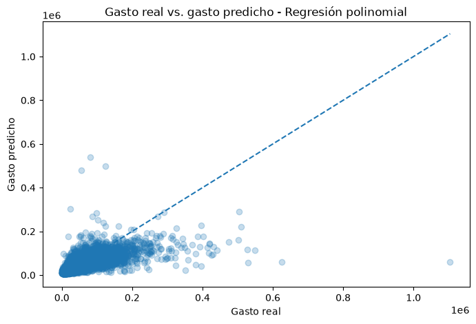

```python
plt.figure(figsize=(8, 5))

plt.scatter(
    y_test_original,
    pred_polinomial_original,
    alpha=0.25
)

limite = max(
    y_test_original.max(),
    pred_polinomial_original.max()
)

plt.plot(
    [0, limite],
    [0, limite],
    linestyle="--"
)

plt.xlabel("Gasto real")
plt.ylabel("Gasto predicho")
plt.title(
    "Gasto real vs. gasto predicho - Regresión polinomial"
)

plt.show()
```

## 8.1 Comparación de los modelos

La regresión polinomial presentó un desempeño ligeramente superior al modelo lineal en todas las métricas evaluadas.

El MAE disminuyó de aproximadamente **$15,006.06** en la regresión lineal a **$14,833.79** en la regresión polinomial. Esto representa una reducción cercana a $172 en el error absoluto promedio.

El RMSE también disminuyó, pasando de aproximadamente **$28,115.70** a **$28,012.57**. La diferencia es relativamente pequeña, lo cual indica que ambos modelos continúan presentando dificultades para estimar algunos hogares con niveles de gasto muy elevados.

El R² en la escala monetaria aumentó de **0.4569** a **0.4609**, mientras que en la escala transformada pasó de **0.5695** a **0.5870**. Por lo tanto, la inclusión de relaciones cuadráticas e interacciones permite capturar parte de la estructura no lineal presente en los datos.

Sin embargo, la mejora predictiva es moderada en comparación con el incremento de complejidad. El modelo lineal utiliza 16 características, mientras que el modelo polinomial utiliza 31 después de incorporar términos cuadrados e interacciones.

Por esta razón, el modelo polinomial puede considerarse ligeramente mejor desde una perspectiva estrictamente predictiva, mientras que el modelo lineal conserva una ventaja importante en simplicidad e interpretación. Esta diferencia será tomada en cuenta posteriormente al realizar el análisis de inferencia.

# 9. Análisis de residuos

Además de las métricas de desempeño, es importante analizar los errores producidos por los modelos. Un residuo representa la diferencia entre el gasto observado y el gasto estimado.

Si un modelo representa adecuadamente la relación presente en los datos, los residuos deberían distribuirse alrededor de cero sin presentar patrones demasiado definidos. También se analizará si los errores aumentan en hogares con niveles de gasto elevados.

```python
residuos_lineal = (
    y_test_original -
    pred_lineal_original
)

residuos_polinomial = (
    y_test_original -
    pred_polinomial_original
)

print("Resumen de residuos:\n")

print("Modelo lineal")
print(f"Media:   ${np.mean(residuos_lineal):,.2f}")
print(f"Mediana: ${np.median(residuos_lineal):,.2f}")

print("\nModelo polinomial")
print(f"Media:   ${np.mean(residuos_polinomial):,.2f}")
print(f"Mediana: ${np.median(residuos_polinomial):,.2f}")
```

```
Resumen de residuos:

Modelo lineal
Media:   $3,418.74
Mediana: $-532.02

Modelo polinomial
Media:   $3,099.63
Mediana: $-371.45
```

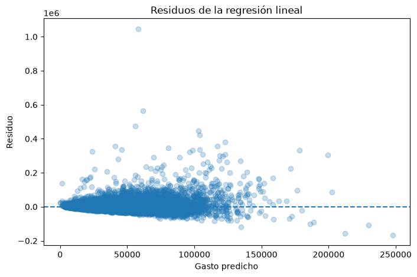

```python
plt.figure(figsize=(8, 5))

plt.scatter(
    pred_lineal_original,
    residuos_lineal,
    alpha=0.25
)

plt.axhline(
    y=0,
    linestyle="--"
)

plt.xlabel("Gasto predicho")
plt.ylabel("Residuo")
plt.title("Residuos de la regresión lineal")

plt.show()
```

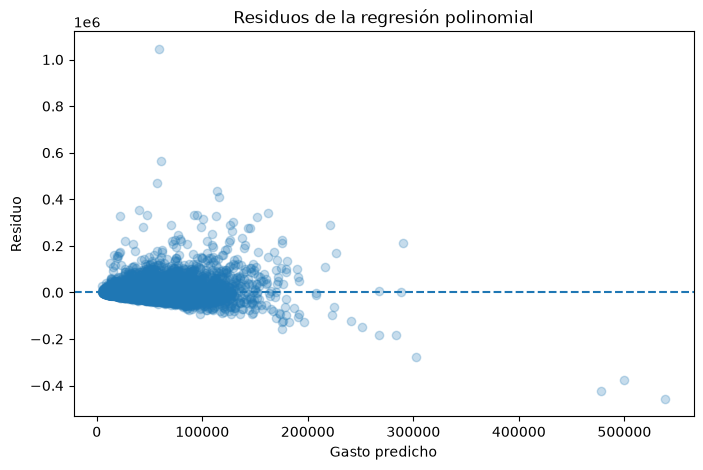

```python
plt.figure(figsize=(8, 5))

plt.scatter(
    pred_polinomial_original,
    residuos_polinomial,
    alpha=0.25
)

plt.axhline(
    y=0,
    linestyle="--"
)

plt.xlabel("Gasto predicho")
plt.ylabel("Residuo")
plt.title("Residuos de la regresión polinomial")

plt.show()
```

```python
mejora_mae = (
    (mae_lineal - mae_polinomial) /
    mae_lineal
) * 100

mejora_rmse = (
    (rmse_lineal - rmse_polinomial) /
    rmse_lineal
) * 100

aumento_r2 = (
    r2_polinomial_original -
    r2_lineal_original
)

print("Mejora del modelo polinomial respecto al lineal:\n")

print(
    f"Reducción porcentual del MAE: "
    f"{mejora_mae:.2f}%"
)

print(
    f"Reducción porcentual del RMSE: "
    f"{mejora_rmse:.2f}%"
)

print(
    f"Aumento absoluto del R² en pesos: "
    f"{aumento_r2:.4f}"
)
```

```
Mejora del modelo polinomial respecto al lineal:

Reducción porcentual del MAE: 1.15%
Reducción porcentual del RMSE: 0.37%
Aumento absoluto del R² en pesos: 0.0040
```

## 9.1 Interpretación del análisis de residuos

Los residuos de ambos modelos se concentran principalmente alrededor de cero, aunque su dispersión aumenta conforme crece el nivel de gasto predicho. Esto indica que los modelos presentan mayor incertidumbre cuando se analizan hogares con gastos elevados.

En el modelo lineal, la media de los residuos fue aproximadamente **$3,418.74**, mientras que en el modelo polinomial disminuyó a **$3,099.63**. Al definirse el residuo como gasto real menos gasto predicho, una media positiva indica que ambos modelos tienden, en promedio, a subestimar parte del gasto observado.

Las medianas de los residuos fueron cercanas a cero y ligeramente negativas, con valores de aproximadamente **-$532.02** para el modelo lineal y **-$371.45** para el modelo polinomial. La diferencia entre la media y la mediana se relaciona con la presencia de algunos errores positivos de gran magnitud.

Las gráficas también muestran que la variabilidad de los residuos no permanece completamente constante. Esta situación sugiere la presencia de heterocedasticidad, especialmente en los niveles de gasto más altos.

La regresión polinomial reduce el MAE aproximadamente **1.15 %** y el RMSE **0.37 %** respecto al modelo lineal, mientras que el R² en la escala monetaria aumenta únicamente **0.0040**. Esto confirma que la mejora existe, pero es moderada.

# 10. Análisis de inferencia estadística

Además de la capacidad predictiva de los modelos, se realizará un análisis de inferencia para estudiar las asociaciones entre las características seleccionadas y el gasto de los hogares.

Para esta etapa se utilizará un modelo de regresión lineal, ya que sus coeficientes permiten analizar de manera directa la dirección y significancia estadística de las asociaciones.

El análisis previo de residuos sugiere que la variabilidad de los errores no es completamente constante. Por esta razón, primero se evaluará formalmente la presencia de heterocedasticidad y posteriormente se utilizarán errores estándar robustos para obtener inferencias e intervalos de confianza más adecuados.

Las asociaciones obtenidas serán interpretadas como relaciones estadísticas dentro de la muestra analizada y no como relaciones causales.

```python
import statsmodels.api as sm
from statsmodels.stats.diagnostic import het_breuschpagan

# Preparar las variables para el modelo de inferencia
X_inferencia = sm.add_constant(X_train_sel)

modelo_inferencia_base = sm.OLS(
    y_train,
    X_inferencia
).fit()

# Prueba de Breusch-Pagan
bp_test = het_breuschpagan(
    modelo_inferencia_base.resid,
    modelo_inferencia_base.model.exog
)

nombres_bp = [
    "Estadístico LM",
    "p-value LM",
    "Estadístico F",
    "p-value F"
]

print("Prueba de Breusch-Pagan:\n")

for nombre, valor in zip(nombres_bp, bp_test):
    print(f"{nombre}: {valor:.6g}")
```

```
Prueba de Breusch-Pagan:

Estadístico LM: 1013.26
p-value LM: 1.61852e-205
Estadístico F: 64.2038
p-value F: 5.26804e-207
```

```python
modelo_inferencia = modelo_inferencia_base.get_robustcov_results(
    cov_type="HC3"
)

print(modelo_inferencia.summary())
```

```
                            OLS Regression Results
==============================================================================
Dep. Variable:           gasto_transf   R-squared:                       0.560
Model:                            OLS   Adj. R-squared:                  0.560
Method:                 Least Squares   F-statistic:                     3364.
Date:                Thu, 03 Sep 2026   Prob (F-statistic):               0.00
Time:                        11:00:14   Log-Likelihood:            -2.2749e+05
No. Observations:               73131   AIC:                         4.550e+05
Df Residuals:                   73114   BIC:                         4.552e+05
Df Model:                          16
Covariance Type:                  HC3
=================================================================================
                    coef    std err          t      P>|t|      [0.025      0.975]
---------------------------------------------------------------------------------
const           -36.6717      0.922    -39.780      0.000     -38.479     -34.865
ingreso_log       6.2401      0.092     68.147      0.000       6.061       6.420
tot_integ         0.5537      0.018     31.151      0.000       0.519       0.589
ocupados          0.1591      0.030      5.374      0.000       0.101       0.217
percep_ing        0.1084      0.030      3.598      0.000       0.049       0.168
edad_jefe        -0.0340      0.002    -22.141      0.000      -0.037      -0.031
educa_jefe_3     -0.5516      0.064     -8.598      0.000      -0.677      -0.426
educa_jefe_4     -0.2518      0.056     -4.489      0.000      -0.362      -0.142
educa_jefe_8      1.1056      0.068     16.351      0.000       0.973       1.238
educa_jefe_9      2.1205      0.133     15.931      0.000       1.860       2.381
educa_jefe_10     3.1227      0.093     33.653      0.000       2.941       3.305
educa_jefe_11     5.3538      0.209     25.597      0.000       4.944       5.764
tam_loc_4        -0.3081      0.049     -6.326      0.000      -0.404      -0.213
est_socio_2       0.5210      0.058      9.056      0.000       0.408       0.634
est_socio_3       1.1030      0.082     13.476      0.000       0.943       1.263
est_socio_4       2.7829      0.131     21.213      0.000       2.526       3.040
clase_hog_3      -0.4533      0.055     -8.195      0.000      -0.562      -0.345
==============================================================================
Omnibus:                    14476.205   Durbin-Watson:                   1.992
Prob(Omnibus):                  0.000   Jarque-Bera (JB):           105906.262
Skew:                           0.762   Prob(JB):                         0.00
Kurtosis:                       8.695   Cond. No.                     1.03e+03
==============================================================================

Notes:
[1] Standard Errors are heteroscedasticity robust (HC3)
[2] The condition number is large, 1.03e+03. This might indicate that there are
strong multicollinearity or other numerical problems.
```

```python
intervalos = modelo_inferencia.conf_int()

tabla_inferencia = pd.DataFrame({
    "Variable": X_inferencia.columns,
    "Coeficiente": modelo_inferencia.params,
    "Error_estandar_robusto": modelo_inferencia.bse,
    "p_value": modelo_inferencia.pvalues,
    "IC_95_inferior": intervalos[:, 0],
    "IC_95_superior": intervalos[:, 1]
})

tabla_inferencia["Significativa_5%"] = (
    tabla_inferencia["p_value"] < 0.05
)

tabla_inferencia.round(4)
```

|  | Variable | Coeficiente | Error_estandar_robusto | p_value | IC_95_inferior | IC_95_superior | Significativa_5% |
| --- | --- | --- | --- | --- | --- | --- | --- |
| 0 | const | -36.6717 | 0.9219 | 0.0000 | -38.4785 | -34.8648 | True |
| 1 | ingreso_log | 6.2401 | 0.0916 | 0.0000 | 6.0606 | 6.4196 | True |
| 2 | tot_integ | 0.5537 | 0.0178 | 0.0000 | 0.5189 | 0.5886 | True |
| 3 | ocupados | 0.1591 | 0.0296 | 0.0000 | 0.1011 | 0.2171 | True |
| 4 | percep_ing | 0.1084 | 0.0301 | 0.0003 | 0.0494 | 0.1675 | True |
| 5 | edad_jefe | -0.0340 | 0.0015 | 0.0000 | -0.0370 | -0.0309 | True |
| 6 | educa_jefe_3 | -0.5516 | 0.0641 | 0.0000 | -0.6773 | -0.4258 | True |
| 7 | educa_jefe_4 | -0.2518 | 0.0561 | 0.0000 | -0.3618 | -0.1419 | True |
| 8 | educa_jefe_8 | 1.1056 | 0.0676 | 0.0000 | 0.9731 | 1.2381 | True |
| 9 | educa_jefe_9 | 2.1205 | 0.1331 | 0.0000 | 1.8596 | 2.3813 | True |
| 10 | educa_jefe_10 | 3.1227 | 0.0928 | 0.0000 | 2.9408 | 3.3045 | True |
| 11 | educa_jefe_11 | 5.3538 | 0.2092 | 0.0000 | 4.9439 | 5.7638 | True |
| 12 | tam_loc_4 | -0.3081 | 0.0487 | 0.0000 | -0.4036 | -0.2126 | True |
| 13 | est_socio_2 | 0.5210 | 0.0575 | 0.0000 | 0.4082 | 0.6337 | True |
| 14 | est_socio_3 | 1.1030 | 0.0819 | 0.0000 | 0.9426 | 1.2634 | True |
| 15 | est_socio_4 | 2.7829 | 0.1312 | 0.0000 | 2.5257 | 3.0400 | True |
| 16 | clase_hog_3 | -0.4533 | 0.0553 | 0.0000 | -0.5617 | -0.3449 | True |

## 10.1 Resultados e interpretación del modelo de inferencia

La prueba de Breusch-Pagan presentó un p-value menor a 0.001, por lo que existe evidencia estadística de heterocedasticidad. Este resultado coincide con el patrón observado previamente en las gráficas de residuos. Debido a ello, la inferencia se realizó utilizando errores estándar robustos HC3.

El modelo de inferencia obtuvo un R² de aproximadamente **0.560**, lo que indica que las características incluidas explican alrededor del 56 % de la variabilidad del gasto transformado dentro de la muestra de entrenamiento.

Las 16 características seleccionadas presentaron significancia estadística al nivel del 5 % en este modelo. Además, sus intervalos de confianza al 95 % no incluyen el valor cero, lo que respalda la existencia de asociaciones estadísticas con la variable de respuesta.

Entre los resultados principales destaca `ingreso_log`, con un coeficiente estimado de **6.2401** y un intervalo de confianza del 95 % aproximadamente entre **6.0606 y 6.4196**. Esto muestra una asociación positiva entre el ingreso corriente y el gasto del hogar, manteniendo constantes las demás características incluidas en el modelo.

El número total de integrantes (`tot_integ`) también presentó una asociación positiva, con un coeficiente de **0.5537** y un intervalo de confianza aproximado entre **0.5189 y 0.5886**. De manera similar, el número de ocupados y el número de perceptores de ingreso presentaron coeficientes positivos.

La edad de la persona jefa del hogar presentó un coeficiente negativo de aproximadamente **-0.0340**, con un intervalo de confianza entre **-0.0370 y -0.0309**. Esto indica una asociación negativa pequeña con el gasto transformado al mantener constantes las demás características.

También se observaron diferencias estadísticamente significativas entre distintas categorías educativas, tamaños de localidad, estratos socioeconómicos y clases de hogar respecto a sus categorías de referencia.

Es importante señalar que la variable de respuesta fue transformada mediante raíz cúbica y el ingreso mediante logaritmo. Por ello, los coeficientes no deben interpretarse directamente como cambios en pesos. Su utilidad principal en esta sección es identificar la dirección, magnitud relativa y significancia estadística de las asociaciones.

Finalmente, estas relaciones deben interpretarse como asociaciones y no como efectos causales. El modelo permite identificar características relacionadas con el gasto, pero no demuestra que modificar una de ellas provoque necesariamente un cambio determinado en el gasto del hogar.

```python
tabla_margenes = tabla_inferencia.copy()

tabla_margenes["Margen_error_95"] = (
    tabla_margenes["IC_95_superior"] -
    tabla_margenes["IC_95_inferior"]
) / 2

variables_clave = [
    "ingreso_log",
    "tot_integ",
    "ocupados",
    "percep_ing",
    "edad_jefe",
    "educa_jefe_11",
    "tam_loc_4",
    "est_socio_4",
    "clase_hog_3"
]

tabla_margenes_clave = tabla_margenes[
    tabla_margenes["Variable"].isin(variables_clave)
][
    [
        "Variable",
        "Coeficiente",
        "Margen_error_95",
        "IC_95_inferior",
        "IC_95_superior",
        "p_value"
    ]
]

tabla_margenes_clave.round(4)
```

|  | Variable | Coeficiente | Margen_error_95 | IC_95_inferior | IC_95_superior | p_value |
| --- | --- | --- | --- | --- | --- | --- |
| 1 | ingreso_log | 6.2401 | 0.1795 | 6.0606 | 6.4196 | 0.0000 |
| 2 | tot_integ | 0.5537 | 0.0348 | 0.5189 | 0.5886 | 0.0000 |
| 3 | ocupados | 0.1591 | 0.0580 | 0.1011 | 0.2171 | 0.0000 |
| 4 | percep_ing | 0.1084 | 0.0591 | 0.0494 | 0.1675 | 0.0003 |
| 5 | edad_jefe | -0.0340 | 0.0030 | -0.0370 | -0.0309 | 0.0000 |
| 11 | educa_jefe_11 | 5.3538 | 0.4100 | 4.9439 | 5.7638 | 0.0000 |
| 12 | tam_loc_4 | -0.3081 | 0.0955 | -0.4036 | -0.2126 | 0.0000 |
| 15 | est_socio_4 | 2.7829 | 0.2571 | 2.5257 | 3.0400 | 0.0000 |
| 16 | clase_hog_3 | -0.4533 | 0.1084 | -0.5617 | -0.3449 | 0.0000 |

## 10.2 Revisión de multicolinealidad

El resumen del modelo mostró un número de condición relativamente elevado. Este indicador puede verse afectado tanto por diferencias en las escalas de las variables como por relaciones entre las características.

Para comprobar si existe un problema importante de multicolinealidad se calculará el Factor de Inflación de la Varianza (VIF) para cada característica seleccionada.

```python
from statsmodels.stats.outliers_influence import variance_inflation_factor

X_vif = sm.add_constant(
    X_train_sel.astype(float)
)

resultados_vif = pd.DataFrame({
    "Variable": X_vif.columns[1:],
    "VIF": [
        variance_inflation_factor(
            X_vif.values,
            i
        )
        for i in range(1, X_vif.shape[1])
    ]
})

resultados_vif = resultados_vif.sort_values(
    by="VIF",
    ascending=False
).reset_index(drop=True)

resultados_vif.round(3)
```

|  | Variable | VIF |
| --- | --- | --- |
| 0 | percep_ing | 2.722 |
| 1 | tot_integ | 2.260 |
| 2 | est_socio_3 | 2.242 |
| 3 | ocupados | 2.183 |
| 4 | est_socio_4 | 1.980 |
| 5 | est_socio_2 | 1.927 |
| 6 | ingreso_log | 1.718 |
| 7 | tam_loc_4 | 1.422 |
| 8 | clase_hog_3 | 1.421 |
| 9 | edad_jefe | 1.419 |
| 10 | educa_jefe_10 | 1.406 |
| 11 | educa_jefe_3 | 1.322 |
| 12 | educa_jefe_8 | 1.240 |
| 13 | educa_jefe_4 | 1.219 |
| 14 | educa_jefe_11 | 1.149 |
| 15 | educa_jefe_9 | 1.101 |

Los valores VIF obtenidos se encuentran por debajo de niveles que normalmente indicarían multicolinealidad severa. El valor más alto se encuentra alrededor de 2.7.

Por lo tanto, aunque el resumen del modelo mostró un número de condición elevado, el análisis mediante VIF no indica un problema grave de multicolinealidad entre las características finalmente utilizadas. Parte del número de condición puede relacionarse con las diferentes escalas y codificaciones presentes en las variables.

# 11. Limitaciones del análisis

Aunque los modelos permiten identificar patrones importantes, existen varias limitaciones que deben considerarse al interpretar los resultados.

En primer lugar, ninguna de las variables disponibles permite explicar completamente el comportamiento del gasto. Incluso el mejor modelo predictivo obtuvo un R² de aproximadamente 0.46 en la escala monetaria original, por lo que una parte importante de la variabilidad depende de factores que no fueron incluidos en el análisis.

También se observó que los modelos presentan mayor dificultad para estimar hogares con gastos excepcionalmente altos. Estos valores generan errores de mayor magnitud y explican en parte la diferencia observada entre el MAE y el RMSE.

Otra limitación corresponde a las transformaciones aplicadas al ingreso y al gasto. Estas transformaciones mejoraron el comportamiento estadístico de las variables, pero hacen que la interpretación directa de algunos coeficientes sea menos intuitiva.

Además, la ENIGH utiliza un diseño muestral complejo. El modelo inferencial desarrollado en este proyecto utiliza errores estándar robustos para tratar la heterocedasticidad, pero no reproduce completamente el esquema oficial de ponderación, estratificación y conglomerados de la encuesta. Por esta razón, las inferencias realizadas deben entenderse principalmente dentro de la muestra analizada y no como estimaciones oficiales para toda la población mexicana.

Finalmente, los resultados corresponden a información de la ENIGH 2024. Las relaciones observadas pueden cambiar en otros periodos debido a modificaciones en precios, ingresos, condiciones económicas y comportamiento de los hogares.

# 12. Conclusiones

El objetivo de este proyecto fue analizar qué características económicas y demográficas están relacionadas con el gasto corriente monetario de los hogares y evaluar qué tan bien puede estimarse mediante modelos de regresión.

A partir de 91,414 hogares de la ENIGH 2024 se realizó un proceso de exploración, preparación y selección de características. Durante esta etapa se identificaron problemas importantes como valores extremos, fuerte asimetría, variables categóricas codificadas numéricamente, redundancia entre características y riesgo de fuga de información.

Para reducir la asimetría se aplicó una transformación de raíz cúbica al gasto y una transformación logarítmica al ingreso. Posteriormente, mediante selección de características y validación cruzada, se eligieron 16 variables para construir los modelos.

La regresión lineal obtuvo un MAE de aproximadamente **$15,006.06**, un RMSE de **$28,115.70** y un R² de **0.4569** en la escala monetaria original.

La regresión polinomial presentó resultados ligeramente mejores, con un MAE de aproximadamente **$14,833.79**, un RMSE de **$28,012.57** y un R² de **0.4609**. Por lo tanto, el modelo no lineal fue el mejor desde el punto de vista predictivo, aunque la mejora respecto al modelo lineal fue moderada.

El análisis inferencial mostró que el ingreso corriente es una de las características con mayor asociación positiva con el gasto. También se identificaron asociaciones relacionadas con el tamaño del hogar, número de ocupados, perceptores de ingreso, edad de la persona jefa, educación, estrato socioeconómico, tamaño de localidad y clase de hogar.

Los resultados muestran que el gasto de los hogares no depende de una sola característica, sino de una combinación de factores económicos y demográficos. Al mismo tiempo, el desempeño de los modelos demuestra que existe una parte importante del gasto que no puede explicarse únicamente con las variables consideradas.

En conclusión, los modelos de regresión permiten caracterizar parte del comportamiento del gasto de los hogares y generar predicciones útiles, pero deben interpretarse considerando la presencia de valores extremos, la incertidumbre en hogares con gastos elevados y las limitaciones del alcance inferencial.

# 13. Reflexión final y trabajo futuro

Este proyecto muestra que el desarrollo de un modelo de regresión no consiste únicamente en ajustar un algoritmo. La exploración, preparación y selección de los datos influyen directamente en la calidad y en la interpretación de los resultados.

También fue posible observar que un modelo más complejo no necesariamente produce una mejora considerable. La regresión polinomial obtuvo mejores métricas que la regresión lineal, pero la diferencia fue pequeña. Esto demuestra la importancia de considerar conjuntamente el desempeño, la complejidad y la interpretabilidad al elegir un modelo.

Como trabajo futuro sería útil incorporar otras características disponibles en las diferentes tablas de la ENIGH, evaluar información de distintos años y analizar por separado grupos de hogares o regiones del país. También podría desarrollarse una inferencia que considere de manera completa el diseño muestral de la encuesta, incluyendo ponderación, estratificación y unidades primarias de muestreo.

Otra posibilidad sería evaluar modelos no lineales adicionales y comparar si pueden mejorar la predicción de los hogares con niveles de gasto particularmente elevados.

# 14. Análisis adicional: escenarios hipotéticos

Como componente adicional se realizará un análisis de escenarios (*what-if*) utilizando el modelo polinomial, que presentó el mejor desempeño predictivo.

El objetivo es observar cómo cambia la estimación del gasto cuando se consideran diferentes niveles de ingreso corriente, manteniendo constantes las demás características de un hogar representativo.

Los niveles de ingreso utilizados no se elegirán arbitrariamente. Se tomarán percentiles de la distribución real de ingresos de la ENIGH 2024, lo que permite construir escenarios basados en valores presentes en los propios datos.

```python
# Niveles de ingreso basados en percentiles reales de la base
percentiles = [0.10, 0.25, 0.50, 0.75, 0.90]

niveles_ingreso = (
    df["ing_cor"]
    .quantile(percentiles)
    .values
)

# Crear un hogar representativo a partir de valores típicos
hogar_base = {}

for variable in X_train_sel.columns:
    if variable in variables_dummy_seleccionadas:
        hogar_base[variable] = X_train_sel[variable].mode()[0]
    else:
        hogar_base[variable] = X_train_sel[variable].median()

# Crear un escenario para cada nivel de ingreso
escenarios = pd.DataFrame(
    [hogar_base.copy() for _ in niveles_ingreso]
)

# Cambiar únicamente el ingreso
escenarios["ingreso_log"] = np.log1p(niveles_ingreso)

# Crear los términos polinomiales de las variables numéricas
escenarios_num_poly = poly.transform(
    escenarios[variables_numericas_seleccionadas]
)

escenarios_poly = pd.DataFrame(
    escenarios_num_poly,
    columns=poly.get_feature_names_out(
        variables_numericas_seleccionadas
    )
)

# Agregar las variables dummy
escenarios_poly = pd.concat(
    [
        escenarios_poly.reset_index(drop=True),
        escenarios[
            variables_dummy_seleccionadas
        ].reset_index(drop=True)
    ],
    axis=1
)

# Mantener exactamente el mismo orden de columnas usado al entrenar
escenarios_poly = escenarios_poly[
    X_train_poly.columns
]

# Realizar predicciones
pred_escenarios_transf = modelo_polinomial.predict(
    escenarios_poly
)

pred_escenarios = np.maximum(
    np.power(pred_escenarios_transf, 3),
    0
)

resultados_escenarios = pd.DataFrame({
    "Percentil_ingreso": [
        "P10",
        "P25",
        "P50",
        "P75",
        "P90"
    ],
    "Ingreso_trimestral": niveles_ingreso,
    "Gasto_estimado_trimestral": pred_escenarios
})

resultados_escenarios.round(2)
```

|  | Percentil_ingreso | Ingreso_trimestral | Gasto_estimado_trimestral |
| --- | --- | --- | --- |
| 0 | P10 | 21976.97 | 20537.36 |
| 1 | P25 | 34520.87 | 26265.20 |
| 2 | P50 | 55666.18 | 34660.07 |
| 3 | P75 | 88840.73 | 45967.82 |
| 4 | P90 | 135664.80 | 59676.58 |

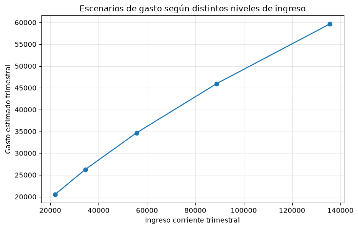

```python
plt.figure(figsize=(8, 5))

plt.plot(
    resultados_escenarios["Ingreso_trimestral"],
    resultados_escenarios["Gasto_estimado_trimestral"],
    marker="o"
)

plt.xlabel("Ingreso corriente trimestral")
plt.ylabel("Gasto estimado trimestral")
plt.title("Escenarios de gasto según distintos niveles de ingreso")

plt.grid(alpha=0.3)

plt.show()
```

## 14.1 Interpretación de los escenarios

Los escenarios hipotéticos muestran una relación creciente entre el ingreso corriente trimestral y el gasto estimado por el modelo polinomial.

Para un hogar representativo ubicado en el percentil 10 de ingreso, con aproximadamente **$21,976.97** trimestrales, el modelo estima un gasto cercano a **$20,537.36**. En el percentil 50, correspondiente a un ingreso de aproximadamente **$55,666.18**, el gasto estimado aumenta a **$34,660.07**.

En los niveles superiores de ingreso, el percentil 90 presenta aproximadamente **$135,664.80** de ingreso trimestral y un gasto estimado de **$59,676.58**.

Este ejercicio permite visualizar de manera sencilla cómo cambia la predicción del gasto al modificar únicamente el nivel de ingreso y mantener constantes las demás características del hogar representativo.

Los resultados son escenarios generados por el modelo y no deben interpretarse como una relación causal. Su objetivo es comunicar de manera práctica el comportamiento aprendido por el modelo a partir de los datos de la ENIGH 2024.

# 15. Referencias

Instituto Nacional de Estadística y Geografía (INEGI). (2025). *Encuesta Nacional de Ingresos y Gastos de los Hogares (ENIGH) 2024*.  
https://www.inegi.org.mx/programas/enigh/nc/2024/

Instituto Nacional de Estadística y Geografía (INEGI). (2025). *ENIGH 2024. Diccionario de datos: concentradohogar*.  
https://www.inegi.org.mx/rnm/index.php/catalog/1116/data-dictionary/F34

Instituto Nacional de Estadística y Geografía (INEGI). (2025). *ENIGH 2024. Descripción de la base de datos*.  
https://www.inegi.org.mx/contenidos/programas/enigh/nc/2024/microdatos/889463924494.pdf

Instituto Nacional de Estadística y Geografía (INEGI). (2025). *ENIGH 2024. Diseño muestral*.  
https://www.inegi.org.mx/contenidos/programas/enigh/nc/2024/doc/889463924517.pdf